# Regression

Sara

May 15, 2018

#### The working directory was set and the cleaned data loaded.

```r
setwd("C:/Users/saraa/Desktop")
fmdata <- read.csv("fe_local_clean.csv")
library(ggplot2)
library(caret)
```

### 1. How do you frame your main question as a machine learning problem? Is it a supervised or unsupervised problem? If it is supervised, is it a regression or a classification?

### Which machine learning technique will you use?

#### I choose to use supervised machine learning, specifically linear regression, because the outcome, the difference in markets per 1,000 people between 2009 and 2016, has an infinite number of possible values.

### 2. What are the main features (also called independent variables or predictors) that you’ll use?

#### Predictors include Produce1000, Animal1000, Baked1000, OtherFood1000, CreditCards1000, SNAP1000, WIC1000, WICCash1000, and Senior1000.

```r
model1 = lm(Difference ~ Produce1000 + Animal1000 + Baked1000 + OtherFood1000 + CreditCards1000 + SNAP1000 +
              WIC1000 + WICCash1000 + Senior1000, data=fmdata)
summary(model1)
```

```
##
## Call:
## lm(formula = Difference ~ Produce1000 + Animal1000 + Baked1000 +
##     OtherFood1000 + CreditCards1000 + SNAP1000 + WIC1000 + WICCash1000 +
##     Senior1000, data = fmdata)
##
## Residuals:
##      Min       1Q   Median       3Q      Max
## -0.61866 -0.01266 -0.00966  0.00507  1.18332
##
## Coefficients:
##                  Estimate Std. Error t value Pr(>|t|)
## (Intercept)      0.009663   0.001417   6.817 1.11e-11 ***
## Produce1000      0.582753   0.031554  18.469  < 2e-16 ***
## Animal1000      -0.051513   0.021756  -2.368 0.017957 *
## Baked1000       -0.375652   0.031654 -11.867  < 2e-16 ***
## OtherFood1000    0.102663   0.026814   3.829 0.000131 ***
## CreditCards1000 -0.101950   0.018861  -5.405 6.96e-08 ***
## SNAP1000        -0.029640   0.019371  -1.530 0.126097
## WIC1000         -0.132244   0.021285  -6.213 5.88e-10 ***
## WICCash1000     -0.007419   0.020389  -0.364 0.715964
## Senior1000      -0.041806   0.019504  -2.144 0.032148 *
## ---
## Signif. codes:  0 '***' 0.001 '**' 0.01 '*' 0.05 '.' 0.1 ' ' 1
##
## Residual standard error: 0.0729 on 3133 degrees of freedom
## Multiple R-squared:  0.2386, Adjusted R-squared:  0.2364
## F-statistic: 109.1 on 9 and 3133 DF,  p-value: < 2.2e-16
```

```r
SSE1 = sum(model1$residuals^2)
SSE1
```

```
## [1] 16.65076
```

```r
model2 = lm(Difference ~ Produce1000 + Baked1000 + OtherFood1000 + CreditCards1000 + WIC1000, data=fmdata)
summary(model2)
```

```
##
## Call:
## lm(formula = Difference ~ Produce1000 + Baked1000 + OtherFood1000 +
##     CreditCards1000 + WIC1000, data = fmdata)
##
## Residuals:
##      Min       1Q   Median       3Q      Max
## -0.61881 -0.01281 -0.00981  0.00494  1.16397
##
## Coefficients:
##                  Estimate Std. Error t value Pr(>|t|)
## (Intercept)      0.009811   0.001417   6.921 5.40e-12 ***
## Produce1000      0.579882   0.030727  18.872  < 2e-16 ***
## Baked1000       -0.390175   0.031290 -12.470  < 2e-16 ***
## OtherFood1000    0.078026   0.024093   3.238  0.00121 **
## CreditCards1000 -0.127019   0.015781  -8.049 1.17e-15 ***
## WIC1000         -0.178533   0.013321 -13.403  < 2e-16 ***
## ---
## Signif. codes:  0 '***' 0.001 '**' 0.01 '*' 0.05 '.' 0.1 ' ' 1
##
## Residual standard error: 0.07304 on 3137 degrees of freedom
## Multiple R-squared:  0.2347, Adjusted R-squared:  0.2334
## F-statistic: 192.4 on 5 and 3137 DF,  p-value: < 2.2e-16
```

```r
SSE2 = sum(model2$residuals^2)
SSE2
```

```
## [1] 16.73643
```

### Now I will split the data, using 70% as a training sample and 30% as a test saample.

```r
set.seed(150)
fmdata_Split <-createDataPartition(fmdata$Difference, p = 0.7, list=FALSE)
fmdata_Train <- fmdata[fmdata_Split, ]
fmdata_Test <- fmdata[-fmdata_Split, ]

#Build model using train
model3 = lm(Difference ~ Produce1000 + Baked1000 + OtherFood1000 + CreditCards1000 + WIC1000, data=fmdata_Train)
summary(model3)
```

```
##
## Call:
## lm(formula = Difference ~ Produce1000 + Baked1000 + OtherFood1000 +
##     CreditCards1000 + WIC1000, data = fmdata_Train)
##
## Residuals:
##      Min       1Q   Median       3Q      Max
## -0.61740 -0.01340 -0.01140  0.00451  1.18581
##
## Coefficients:
##                  Estimate Std. Error t value Pr(>|t|)
## (Intercept)      0.011398   0.001729   6.594 5.34e-11 ***
## Produce1000      0.493787   0.036877  13.390  < 2e-16 ***
## Baked1000       -0.215234   0.041172  -5.228 1.88e-07 ***
## OtherFood1000    0.013730   0.026617   0.516    0.606
## CreditCards1000 -0.168718   0.018090  -9.327  < 2e-16 ***
## WIC1000         -0.162205   0.015728 -10.313  < 2e-16 ***
## ---
## Signif. codes:  0 '***' 0.001 '**' 0.01 '*' 0.05 '.' 0.1 ' ' 1
##
## Residual standard error: 0.07455 on 2196 degrees of freedom
## Multiple R-squared:  0.2518, Adjusted R-squared:  0.2501
## F-statistic: 147.8 on 5 and 2196 DF,  p-value: < 2.2e-16
```

```r
SSE3 = sum(model3$residuals^2)
SSE3
```

```
## [1] 12.20384
```

### The OtherFood variable is not significant at less than 1, so it too will be removed.

```r
set.seed(150)
fmdata_Split <-createDataPartition(fmdata$Difference, p = 0.7, list=FALSE)
fmdata_Train <- fmdata[fmdata_Split, ]
fmdata_Test <- fmdata[-fmdata_Split, ]

model4 = lm(Difference ~ Produce1000 + Baked1000 + CreditCards1000 + WIC1000, data=fmdata_Train)
summary(model4)
```

```
##
## Call:
## lm(formula = Difference ~ Produce1000 + Baked1000 + CreditCards1000 +
##     WIC1000, data = fmdata_Train)
##
## Residuals:
##      Min       1Q   Median       3Q      Max
## -0.61747 -0.01347 -0.01147  0.00452  1.18771
##
## Coefficients:
##                  Estimate Std. Error t value Pr(>|t|)
## (Intercept)      0.011466   0.001723   6.653 3.60e-11 ***
## Produce1000      0.496173   0.036580  13.564  < 2e-16 ***
## Baked1000       -0.206240   0.037291  -5.531 3.57e-08 ***
## CreditCards1000 -0.167809   0.018000  -9.322  < 2e-16 ***
## WIC1000         -0.161149   0.015591 -10.336  < 2e-16 ***
## ---
## Signif. codes:  0 '***' 0.001 '**' 0.01 '*' 0.05 '.' 0.1 ' ' 1
##
## Residual standard error: 0.07453 on 2197 degrees of freedom
## Multiple R-squared:  0.2517, Adjusted R-squared:  0.2503
## F-statistic: 184.7 on 4 and 2197 DF,  p-value: < 2.2e-16
```

```r
SSE4 = sum(model4$residuals^2)
SSE4
```

```
## [1] 12.20532
```

```r
predictTest <- predict(model4, newdata=fmdata_Test)
```

### How will you evaluate the success of your machine learning technique? What metric will you use?

#### I will see how well my linear regression model can predict the difference in markets per 1,000 people between the years 2009 and 2016 by measuring R^2, which represents the proportion of variability explained by the model. The closer R^2 is to 1, the more precise the prediction.

```r
predictTest <- predict(model4, newdata=fmdata_Test)
SSE4 <- sum((fmdata_Test$Difference - predictTest) ^ 2)
SST4 <- sum((fmdata_Test$Difference - mean(fmdata_Test$Difference)) ^ 2)
SSE4
```

```
## [1] 4.773735
```

```r
SST4
```

```
## [1] 5.542672
```

```r
SquaredR4 <- 1 - SSE4/SST4
SquaredR4
```

```
## [1] 0.1387305
```

#### Only 13.9% of the variability can be explained by this regression model, so this model is fairly weak at predicting the change in farmer’s markets per 1,000 people.

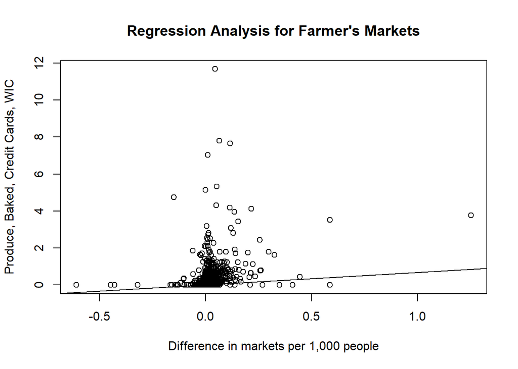

```r
plot(fmdata_Test$Difference, fmdata_Test$Produce1000 + fmdata_Test$Baked1000 + fmdata_Test$CreditCards1000 +
fmdata_Test$WIC1000, main = "Regression Analysis for Farmer's Markets", xlab = "Difference in markets per 1,000 people", ylab = "Produce, Baked, Credit Cards, WIC")

abline(lm(fmdata_Test$Difference ~ fmdata_Test$Produce1000 + fmdata_Test$Baked1000 + fmdata_Test$CreditCards1000 + fmdata_Test$WIC1000))
```

#### As this plot shows, not very many points are close to the line, which shows that this is a weak model. Let’s try using model1, which has all variables.

```r
predictTest <- predict(model1, newdata=fmdata_Test)
SSE1 <- sum((fmdata_Test$Difference - predictTest) ^ 2)
SST1 <- sum((fmdata_Test$Difference - mean(fmdata_Test$Difference)) ^ 2)
SquaredR1 <- 1 - SSE1/SST1
SquaredR1
```

```
## [1] 0.2101556
```

#### This model has a slightly better R-squared value, with 21% of variability explained by the model, though it is still weak even with all variables.

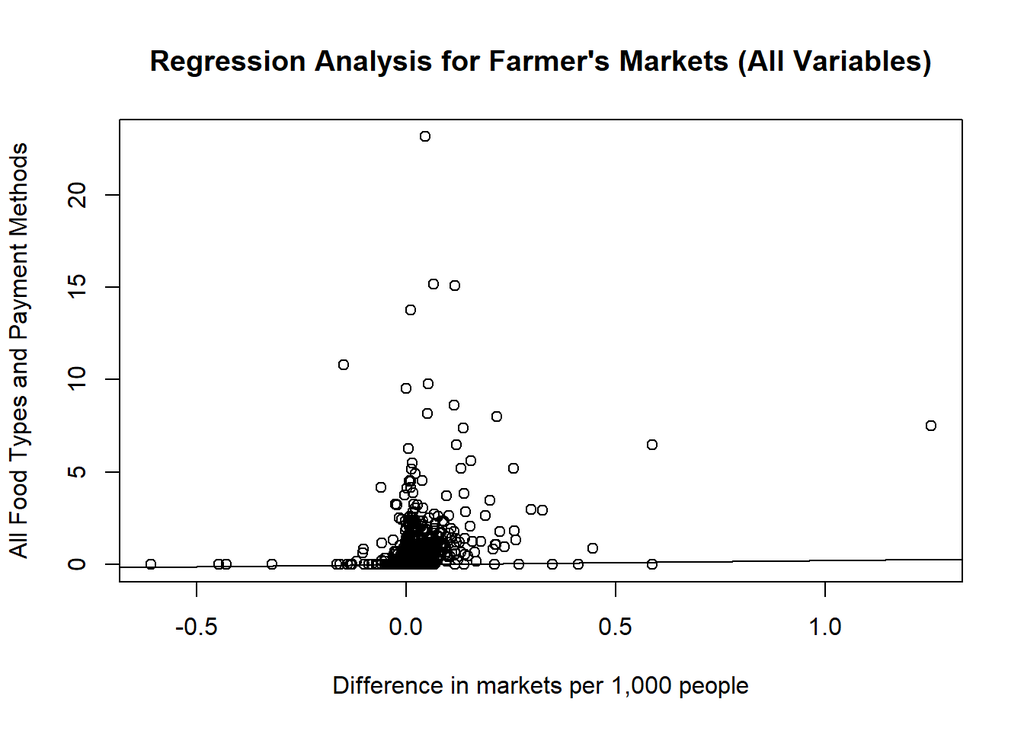

```r
plot(fmdata_Test$Difference, fmdata_Test$Produce1000 + fmdata_Test$Animal1000 + fmdata_Test$Baked1000 +
       fmdata_Test$OtherFood1000 + fmdata_Test$CreditCards1000 + fmdata_Test$SNAP1000 + fmdata_Test$WIC1000 +
       fmdata_Test$WICCash1000 + fmdata_Test$Senior1000, main = "Regression Analysis for Farmer's Markets (All Variables)",
     xlab = "Difference in markets per 1,000 people", ylab = "All Food Types and Payment Methods")

abline(lm(fmdata_Test$Difference ~ fmdata_Test$Produce1000 + fmdata_Test$Animal1000 + fmdata_Test$Baked1000 +
            fmdata_Test$OtherFood1000 + fmdata_Test$CreditCards1000 + fmdata_Test$SNAP1000 +
            fmdata_Test$WIC1000 + fmdata_Test$WICCash1000 + fmdata_Test$Senior1000))
```

#### Compared to the previous plot, this plot has a slightly greater share of points close to the line, showing that using all variables leads to a slightly stronger model.

#### Now let’s try excluding the outliers. This will involve excluding the values in the “normalized” columns greater than 1.5 or less than -1.5.

```r
fmdata_decimals <- data.frame(fmdata$SNAP1000, fmdata$WIC1000, fmdata$WICCash1000, fmdata$Senior1000,
                              fmdata$CreditCards1000, fmdata$Produce1000, fmdata$Animal1000, fmdata$Baked1000,
                              fmdata$OtherFood1000, fmdata$Difference, fmdata$Markets_2009_norm,
                              fmdata$Markets_2016_norm, fmdata$SNAP_norm, fmdata$WIC_norm,
                              fmdata$WICCash_norm, fmdata$Senior_norm, fmdata$CreditCards_norm,
                              fmdata$Produce_norm, fmdata$Animal_norm, fmdata$Baked_norm,
                              fmdata$OtherFood_norm)

Markets_no_outliers <- fmdata_decimals[fmdata_decimals$fmdata.Markets_2009_norm <= 1.5,]
Markets_no_outliers <- Markets_no_outliers[Markets_no_outliers$fmdata.Markets_2009_norm >= -1.5,]
Markets_no_outliers <- Markets_no_outliers[Markets_no_outliers$fmdata.Markets_2016_norm <= 1.5,]
Markets_no_outliers <- Markets_no_outliers[Markets_no_outliers$fmdata.Markets_2016_norm >= -1.5,]
Markets_no_outliers <- Markets_no_outliers[Markets_no_outliers$fmdata.SNAP_norm <= 1.5,]
Markets_no_outliers <- Markets_no_outliers[Markets_no_outliers$fmdata.SNAP_norm >= -1.5,]
Markets_no_outliers <- Markets_no_outliers[Markets_no_outliers$fmdata.WIC_norm <= 1.5,]
Markets_no_outliers <- Markets_no_outliers[Markets_no_outliers$fmdata.WIC_norm >= -1.5,]
Markets_no_outliers <- Markets_no_outliers[Markets_no_outliers$fmdata.WICCash_norm <= 1.5,]
Markets_no_outliers <- Markets_no_outliers[Markets_no_outliers$fmdata.WICCash_norm >= -1.5,]
Markets_no_outliers <- Markets_no_outliers[Markets_no_outliers$fmdata.Senior_norm <= 1.5,]
Markets_no_outliers <- Markets_no_outliers[Markets_no_outliers$fmdata.Senior_norm >= -1.5,]
Markets_no_outliers <- Markets_no_outliers[Markets_no_outliers$fmdata.CreditCards_norm <= 1.5,]
Markets_no_outliers <- Markets_no_outliers[Markets_no_outliers$fmdata.CreditCards_norm >= -1.5,]
Markets_no_outliers <- Markets_no_outliers[Markets_no_outliers$fmdata.Produce_norm <= 1.5,]
Markets_no_outliers <- Markets_no_outliers[Markets_no_outliers$fmdata.Produce_norm >= -1.5,]
Markets_no_outliers <- Markets_no_outliers[Markets_no_outliers$fmdata.Animal_norm <= 1.5,]
Markets_no_outliers <- Markets_no_outliers[Markets_no_outliers$fmdata.Animal_norm >= -1.5,]
Markets_no_outliers <- Markets_no_outliers[Markets_no_outliers$fmdata.Baked_norm <= 1.5,]
Markets_no_outliers <- Markets_no_outliers[Markets_no_outliers$fmdata.Baked_norm >= -1.5,]
Markets_no_outliers <- Markets_no_outliers[Markets_no_outliers$fmdata.OtherFood_norm <= 1.5,]
Markets_no_outliers <- Markets_no_outliers[Markets_no_outliers$fmdata.OtherFood_norm >= -1.5,]
```

#### Now build the model.

```r
model5 = lm(fmdata.Difference ~ fmdata.Produce1000 + fmdata.Animal1000 + fmdata.Baked1000 +
              fmdata.OtherFood1000 + fmdata.CreditCards1000 + fmdata.SNAP1000 + fmdata.WIC1000 +
              fmdata.WICCash1000 + fmdata.Senior1000, data=Markets_no_outliers)
summary(model5)
```

```
##
## Call:
## lm(formula = fmdata.Difference ~ fmdata.Produce1000 + fmdata.Animal1000 +
##     fmdata.Baked1000 + fmdata.OtherFood1000 + fmdata.CreditCards1000 +
##     fmdata.SNAP1000 + fmdata.WIC1000 + fmdata.WICCash1000 + fmdata.Senior1000,
##     data = Markets_no_outliers)
##
## Residuals:
##      Min       1Q   Median       3Q      Max
## -0.61235 -0.01135 -0.00635  0.00651  0.73679
##
## Coefficients:
##                         Estimate Std. Error t value Pr(>|t|)
## (Intercept)             0.006355   0.002920   2.176  0.02990 *
## fmdata.Produce1000     -0.175668   0.107506  -1.634  0.10273
## fmdata.Animal1000      -0.128993   0.055213  -2.336  0.01978 *
## fmdata.Baked1000        0.187395   0.092494   2.026  0.04317 *
## fmdata.OtherFood1000    0.360881   0.113913   3.168  0.00161 **
## fmdata.CreditCards1000 -0.021277   0.042304  -0.503  0.61517
## fmdata.SNAP1000         0.233629   0.040457   5.775 1.19e-08 ***
## fmdata.WIC1000         -0.224953   0.050675  -4.439 1.06e-05 ***
## fmdata.WICCash1000     -0.119899   0.061070  -1.963  0.05003 .
## fmdata.Senior1000      -0.083375   0.058590  -1.423  0.15520
## ---
## Signif. codes:  0 '***' 0.001 '**' 0.01 '*' 0.05 '.' 0.1 ' ' 1
##
## Residual standard error: 0.06619 on 655 degrees of freedom
## Multiple R-squared:  0.3361, Adjusted R-squared:  0.327
## F-statistic: 36.84 on 9 and 655 DF,  p-value: < 2.2e-16
```

```r
SSE5 = sum(model5$residuals^2)
SSE5
```

```
## [1] 2.869927
```

```r
model6 = lm(fmdata.Difference ~ fmdata.Animal1000 + fmdata.OtherFood1000 + fmdata.WIC1000, data=Markets_no_outliers)
summary(model6)
```

```
##
## Call:
## lm(formula = fmdata.Difference ~ fmdata.Animal1000 + fmdata.OtherFood1000 +
##     fmdata.WIC1000, data = Markets_no_outliers)
##
## Residuals:
##      Min       1Q   Median       3Q      Max
## -0.61078 -0.01051 -0.00478  0.00484  0.93475
##
## Coefficients:
##                       Estimate Std. Error t value Pr(>|t|)
## (Intercept)           0.004785   0.002946   1.624    0.105
## fmdata.Animal1000    -0.002827   0.050117  -0.056    0.955
## fmdata.OtherFood1000  0.315027   0.045938   6.858 1.61e-11 ***
## fmdata.WIC1000       -0.301125   0.029404 -10.241  < 2e-16 ***
## ---
## Signif. codes:  0 '***' 0.001 '**' 0.01 '*' 0.05 '.' 0.1 ' ' 1
##
## Residual standard error: 0.06816 on 661 degrees of freedom
## Multiple R-squared:  0.2896, Adjusted R-squared:  0.2864
## F-statistic: 89.83 on 3 and 661 DF,  p-value: < 2.2e-16
```

```r
SSE6 = sum(model6$residuals^2)
SSE6
```

```
## [1] 3.070789
```

```r
set.seed(150)
no_outlier_Split <-createDataPartition(Markets_no_outliers$fmdata.Difference, p = 0.7, list=FALSE)
no_outlier_Train <- Markets_no_outliers[no_outlier_Split, ]
no_outlier_Test <- Markets_no_outliers[-no_outlier_Split, ]

model7 = lm(fmdata.Difference ~ fmdata.Produce1000 + fmdata.Animal1000 + fmdata.Baked1000 +
              fmdata.OtherFood1000 + fmdata.CreditCards1000 + fmdata.SNAP1000 + fmdata.WIC1000 +
              fmdata.WICCash1000 + fmdata.Senior1000, data=no_outlier_Train)
summary(model7)
```

```
##
## Call:
## lm(formula = fmdata.Difference ~ fmdata.Produce1000 + fmdata.Animal1000 +
##     fmdata.Baked1000 + fmdata.OtherFood1000 + fmdata.CreditCards1000 +
##     fmdata.SNAP1000 + fmdata.WIC1000 + fmdata.WICCash1000 + fmdata.Senior1000,
##     data = no_outlier_Train)
##
## Residuals:
##      Min       1Q   Median       3Q      Max
## -0.61571 -0.01185 -0.00971  0.00650  0.35129
##
## Coefficients:
##                         Estimate Std. Error t value Pr(>|t|)
## (Intercept)             0.009707   0.003084   3.147  0.00176 **
## fmdata.Produce1000     -0.018128   0.109138  -0.166  0.86815
## fmdata.Animal1000      -0.193541   0.062224  -3.110  0.00199 **
## fmdata.Baked1000        0.215441   0.099311   2.169  0.03057 *
## fmdata.OtherFood1000    0.093092   0.116353   0.800  0.42408
## fmdata.CreditCards1000  0.074133   0.047745   1.553  0.12119
## fmdata.SNAP1000        -0.086842   0.051843  -1.675  0.09460 .
## fmdata.WIC1000         -0.072984   0.064899  -1.125  0.26136
## fmdata.WICCash1000     -0.003976   0.072380  -0.055  0.95622
## fmdata.Senior1000      -0.026381   0.069727  -0.378  0.70535
## ---
## Signif. codes:  0 '***' 0.001 '**' 0.01 '*' 0.05 '.' 0.1 ' ' 1
##
## Residual standard error: 0.05841 on 458 degrees of freedom
## Multiple R-squared:  0.168,  Adjusted R-squared:  0.1517
## F-statistic: 10.28 on 9 and 458 DF,  p-value: 1.717e-14
```

```r
SSE7 = sum(model7$residuals^2)
SSE7
```

```
## [1] 1.562519
```

```r
predictTest <- predict(model7, newdata=no_outlier_Test)
```

```r
set.seed(150)
no_outlier_Split <-createDataPartition(Markets_no_outliers$fmdata.Difference, p = 0.7, list=FALSE)
no_outlier_Train <- Markets_no_outliers[no_outlier_Split, ]
no_outlier_Test <- Markets_no_outliers[-no_outlier_Split, ]

model8 = lm(fmdata.Difference ~ fmdata.CreditCards1000 + fmdata.WIC1000 +
              fmdata.WICCash1000 + fmdata.Senior1000, data=no_outlier_Train)
summary(model8)
```

```
##
## Call:
## lm(formula = fmdata.Difference ~ fmdata.CreditCards1000 + fmdata.WIC1000 +
##     fmdata.WICCash1000 + fmdata.Senior1000, data = no_outlier_Train)
##
## Residuals:
##      Min       1Q   Median       3Q      Max
## -0.61862 -0.01362 -0.01262  0.00659  0.42938
##
## Coefficients:
##                        Estimate Std. Error t value Pr(>|t|)
## (Intercept)             0.01262    0.00323   3.907 0.000107 ***
## fmdata.CreditCards1000  0.13016    0.02634   4.942 1.08e-06 ***
## fmdata.WIC1000         -0.10326    0.06495  -1.590 0.112544
## fmdata.WICCash1000     -0.10512    0.07504  -1.401 0.161949
## fmdata.Senior1000       0.04957    0.06795   0.730 0.466042
## ---
## Signif. codes:  0 '***' 0.001 '**' 0.01 '*' 0.05 '.' 0.1 ' ' 1
##
## Residual standard error: 0.06201 on 463 degrees of freedom
## Multiple R-squared:  0.05215,    Adjusted R-squared:  0.04396
## F-statistic: 6.369 on 4 and 463 DF,  p-value: 5.388e-05
```

```r
SSE8 = sum(model8$residuals^2)
SSE8
```

```
## [1] 1.780163
```

```r
predictTest <- predict(model8, newdata=no_outlier_Test)
```

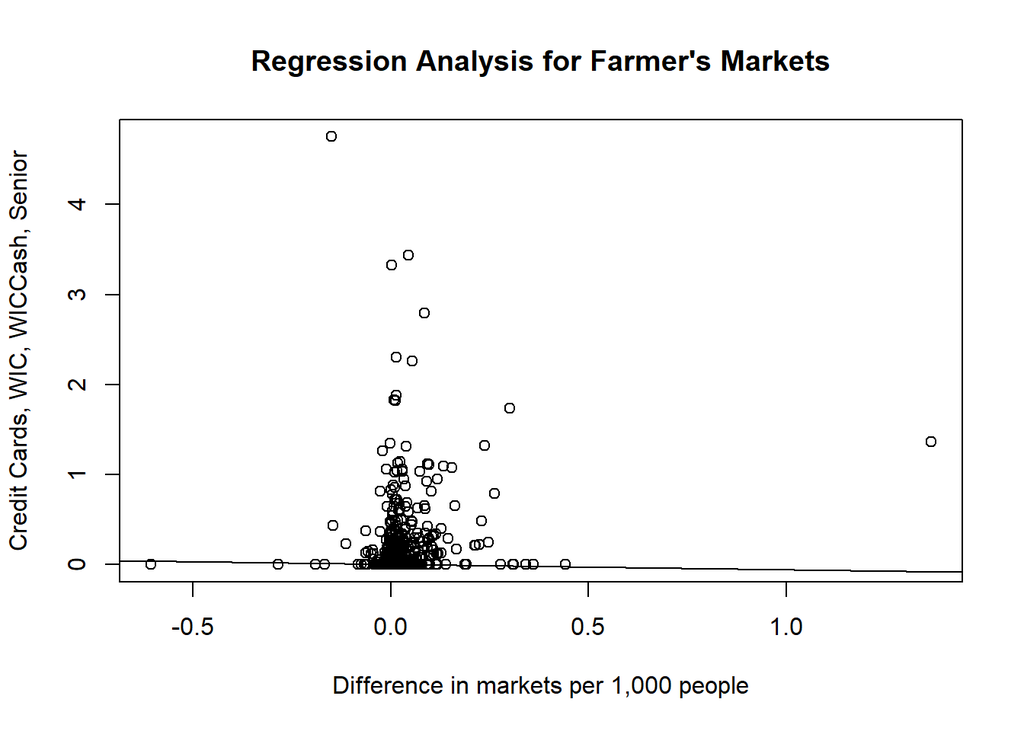

```r
plot(Markets_no_outliers$fmdata.Difference, Markets_no_outliers$fmdata.CreditCards1000 +
       Markets_no_outliers$fmdata.WIC1000 + Markets_no_outliers$fmdata.WICCash1000 + Markets_no_outliers$fmdata.Senior1000, main = "Regression Analysis for Farmer's Markets", xlab = "Difference in markets per 1,000 people", ylab = "Credit Cards, WIC, WICCash, Senior")

abline(lm(Markets_no_outliers$fmdata.Difference ~ Markets_no_outliers$fmdata.Animal1000 +
       Markets_no_outliers$fmdata.OtherFood1000))
```